# Mid-Term Project

## Q2. Evaluate the HCP behavior in context of claim volume from 2016-2018. How many HCPs are submitting 1 CVM claim; how many HCPs are associated with more than 10 claims, etc.? Once you perform this analysis, explain how this trend can influence the sales force deployment. That is, how would you segment the HCPs and how would you allocate In-Person (sales force) vs Non-Personal Promotions (NPP, i.e. Emails, Social Media, Digital etc.) efforts?

```python
import pandas as pd

print("🩺 CARDIAC DATA VALIDATION")
print("=====================================")

# Check record and column details
print(f"Total records: {len(cardiac_uniq_df):,}")
print(f"Columns available: {list(cardiac_uniq_df.columns)}\n")

# Check unique identifiers
unique_hcps = cardiac_uniq_df['npi_id'].nunique()
unique_claims = cardiac_uniq_df['claim_id'].nunique()
print(f"👩‍⚕️ Unique HCPs: {unique_hcps:,}")
print(f"📄 Unique Claims: {unique_claims:,}\n")

# Check for missing data in critical columns
key_cols = ['claim_id', 'npi_id', 'claim_year']
missing_summary = cardiac_uniq_df[key_cols].isna().sum().to_frame('missing_count')
missing_summary['missing_%'] = (missing_summary['missing_count'] / len(cardiac_uniq_df) * 100).round(2)
display(missing_summary)

# Ensure valid numeric claim_years
cardiac_uniq_df['claim_year'] = pd.to_numeric(cardiac_uniq_df['claim_year'], errors='coerce')
cardiac_uniq_df = cardiac_uniq_df[cardiac_uniq_df['claim_year'].between(2016, 2018)]

print(f"\n Filtered claim years: {sorted(cardiac_uniq_df['claim_year'].unique())}")
print(f" Cleaned dataset rows: {len(cardiac_uniq_df):,}")
```

```
🩺 CARDIAC DATA VALIDATION
=====================================
Total records: 15,631
Columns available: ['claim_id', 'patient_id', 'npi_id', 'claim_date', 'hcpcs_code', 'diagnosis_code', 'claim_cost', 'patient_birth_date', 'patient_gender', 'claim_year', 'patient_age']

👩‍⚕️ Unique HCPs: 9,453
📄 Unique Claims: 15,631
```

|  | missing_count | missing_% |
| --- | --- | --- |
| claim_id | 0 | 0.00 |
| npi_id | 1959 | 12.53 |
| claim_year | 0 | 0.00 |

```
 Filtered claim years: [2016, 2017, 2018]
 Cleaned dataset rows: 15,631
```

```python
# Step 1: Count claims per HCP per year
hcp_claims_per_year = (
    cardiac_uniq_df
    .groupby(['npi_id', 'claim_year'])['claim_id']
    .nunique()
    .reset_index(name='claim_count')
)

# Step 2: Dynamically define bins that are always increasing
max_claims = hcp_claims_per_year['claim_count'].max()

# If the highest number of claims ≤ 100, push the last bin slightly higher
bins = [0, 1, 5, 10, 25, 50, 100, max_claims + 1 if max_claims <= 100 else max_claims]

# Ensure bins are strictly increasing (remove duplicates, sort)
bins = sorted(set(bins))

segment_labels = [
    '1 claim', '2–5 claims', '6–10 claims',
    '11–25 claims', '26–50 claims', '51–100 claims', '100+ claims'
]

# Assign segment labels safely
hcp_claims_per_year['hcp_segment'] = pd.cut(
    hcp_claims_per_year['claim_count'],
    bins=bins,
    labels=segment_labels[:len(bins)-1],  # trim to match bins
    include_lowest=True
)

display(hcp_claims_per_year.head())
print(f" Bins used: {bins}")
print(f" Max claim count in dataset: {max_claims}")
```

|  | npi_id | claim_year | claim_count | hcp_segment |
| --- | --- | --- | --- | --- |
| 0 | 1.003018e+09 | 2016 | 1 | 1 claim |
| 1 | 1.003018e+09 | 2017 | 1 | 1 claim |
| 2 | 1.003018e+09 | 2016 | 1 | 1 claim |
| 3 | 1.003020e+09 | 2018 | 1 | 1 claim |
| 4 | 1.003031e+09 | 2017 | 1 | 1 claim |

```
 Bins used: [0, 1, 5, 10, 25, 50, 62, 100]
 Max claim count in dataset: 61
```

```python
# Step 3: Aggregate number of HCPs by year and segment
hcp_segments_summary = (
    hcp_claims_per_year
    .groupby(['claim_year', 'hcp_segment'])['npi_id']
    .nunique()
    .unstack(fill_value=0)
)

# Arrange segment order
hcp_segments_summary = hcp_segments_summary.reindex(columns=[c for c in segment_labels if c in hcp_segments_summary.columns])

print("🩺 HCP Segments per Year — Cardiac Claims (2016–2018)")
display(hcp_segments_summary)
```

```
🩺 HCP Segments per Year — Cardiac Claims (2016–2018)
```

| hcp_segment claim_year | 1 claim | 2–5 claims | 6–10 claims | 11–25 claims | 26–50 claims | 51–100 claims | 100+ claims |
| --- | --- | --- | --- | --- | --- | --- | --- |
| 2016 | 2616 | 247 | 23 | 15 | 1 | 0 | 0 |
| 2017 | 3143 | 318 | 20 | 18 | 3 | 0 | 0 |
| 2018 | 3666 | 388 | 26 | 27 | 7 | 1 | 0 |

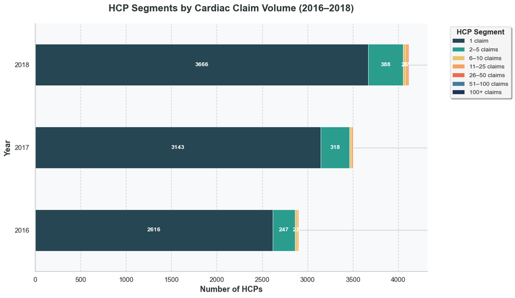

```python
import matplotlib.pyplot as plt
import numpy as np

# Modern, accessible color palette (perceptually uniform)
colors = ['#264653', '#2a9d8f', '#e9c46a', '#f4a261', '#e76f51', '#457b9d', '#1d3557']

# Alternative elegant palette (uncomment to use):
# colors = ['#003f5c', '#58508d', '#bc5090', '#ff6361', '#ffa600', '#488f31', '#004c6d']

# Create horizontal stacked bar chart
fig, ax = plt.subplots(figsize=(12, 7))

hcp_segments_summary.plot(
    kind='barh',
    stacked=True,
    color=colors,
    edgecolor='white',
    linewidth=0.5,
    ax=ax
)

# Improved labels inside each section with better contrast
for container in ax.containers:
    labels = []
    for v in container.datavalues:
        if v > 20:  # Slightly higher threshold for better readability
            # Use white text for darker colors, black for lighter ones
            color = 'white' if np.mean(plt.get_cmap('viridis')(0.7)) < 0.6 else 'black'
            labels.append(f'{int(v)}')
        else:
            labels.append('')
    ax.bar_label(
        container,
        labels=labels,
        label_type='center',
        fontsize=10,
        fontweight='bold',
        color='white'  # Using white for all for consistency with dark colors
    )

# Enhanced chart formatting
plt.title(
    'HCP Segments by Cardiac Claim Volume (2016–2018)',
    fontsize=16,
    fontweight='bold',
    pad=20,
    color='#2d3436'
)

plt.ylabel('Year', fontsize=13, fontweight='bold', color='#2d3436')
plt.xlabel('Number of HCPs', fontsize=13, fontweight='bold', color='#2d3436')

# Improved legend
legend = plt.legend(
    title='HCP Segment',
    bbox_to_anchor=(1.05, 1),
    loc='upper left',
    fontsize=10,
    frameon=True,
    fancybox=True,
    shadow=True,
    framealpha=0.9
)
legend.get_title().set_fontweight('bold')

# Enhanced grid
plt.grid(axis='x', linestyle='--', alpha=0.3, color='gray')

# Remove spines for cleaner look
ax.spines['top'].set_visible(False)
ax.spines['right'].set_visible(False)
ax.spines['left'].set_visible(True)
ax.spines['bottom'].set_visible(True)

# Better tick formatting
plt.xticks(fontsize=11)
plt.yticks(fontsize=11)

# Add some padding
plt.tight_layout()

# Optional: Add a subtle background
ax.set_facecolor('#f8f9fa')
fig.patch.set_facecolor('white')

plt.show()
```

Based on the cardiac claim data analysis, HCPs segment into three distinct engagement tiers that should drive differentiated commercial strategies. The foundation consists of occasional prescribers (1-10 claims annually) who represent the broadest segment but contribute minimal individual volume—ideal for efficient digital engagement through automated outreach and virtual detailing. In contrast, a crucial middle tier of consistent contributors (11-50 claims) warrants balanced personal and digital support to nurture growth, while the elite specialists submitting 51+ claims annually—though smallest in number—deliver disproportionate value and justify intensive, high-touch relationships with dedicated account managers and premium resources.

This segmentation reveals a clear commercial imperative: align resource allocation with revenue potential. Field force efforts should concentrate on high-value specialists through personalized engagement, while digital channels efficiently maintain broader market coverage with occasional prescribers. Regular monitoring of claim patterns will enable dynamic resource reallocation, ensuring marketing investments continuously adapt to evolving prescribing behaviors across these distinct HCP segments for optimal return.

## Q3. Evaluate the Patient Age demographics in the context of claim volume from 2016-2018. Bucket the patients into groups based on their age and explain the trends. How would you position the Marketing Budgets and the Promotions with respect to the changing landscape of the CVM claims and the respective patient segments?

```python
import pandas as pd

# 1️⃣ Ensure claim_year is numeric
cardiac_uniq_df['claim_year'] = pd.to_numeric(cardiac_uniq_df['claim_year'], errors='coerce')

# 2️⃣ Derive from claim_date if missing
if 'claim_year' not in cardiac_uniq_df.columns and 'claim_date' in cardiac_uniq_df.columns:
    cardiac_uniq_df['claim_year'] = pd.to_datetime(cardiac_uniq_df['claim_date'], errors='coerce').dt.year

# 3️⃣ Confirm valid years
cardiac_uniq_df = cardiac_uniq_df[cardiac_uniq_df['claim_year'].between(2016, 2018)]

# 4️⃣ Pick the correct patient-age column
age_col = 'age' if 'age' in cardiac_uniq_df.columns else 'patient_age'

# 5️⃣ Define age buckets
age_bins = [0, 59, 69, 79, 120]
age_labels = ['18–59', '60–69', '70–79', '80+']

cardiac_uniq_df['age_group'] = pd.cut(
    cardiac_uniq_df[age_col],
    bins=age_bins,
    labels=age_labels,
    include_lowest=True
)

print(" Age buckets assigned successfully.")
display(cardiac_uniq_df[['claim_year', age_col, 'age_group']].head())
```

```
 Age buckets assigned successfully.
```

|  | claim_year | patient_age | age_group |
| --- | --- | --- | --- |
| 43 | 2018 | 52 | 18–59 |
| 50 | 2017 | 69 | 60–69 |
| 82 | 2017 | 78 | 70–79 |
| 110 | 2017 | 77 | 70–79 |
| 151 | 2016 | 65 | 60–69 |

```python
# Aggregate number of unique claims by claim_year and age_group
cardiac_age_claims = (
    cardiac_uniq_df
    .groupby(['claim_year', 'age_group'], observed=False)['claim_id']
    .nunique()
    .reset_index(name='claim_count')
    .sort_values(['claim_year', 'age_group'])
)

print("📊 Cardiac Claim Counts by Year & Age Group")
display(cardiac_age_claims)
```

```
📊 Cardiac Claim Counts by Year & Age Group
```

|  | claim_year | age_group | claim_count |
| --- | --- | --- | --- |
| 0 | 2016 | 18–59 | 288 |
| 1 | 2016 | 60–69 | 1360 |
| 2 | 2016 | 70–79 | 1326 |
| 3 | 2016 | 80+ | 1221 |
| 4 | 2017 | 18–59 | 279 |
| 5 | 2017 | 60–69 | 1530 |
| 6 | 2017 | 70–79 | 1967 |
| 7 | 2017 | 80+ | 1369 |
| 8 | 2018 | 18–59 | 386 |
| 9 | 2018 | 60–69 | 1758 |
| 10 | 2018 | 70–79 | 2211 |
| 11 | 2018 | 80+ | 1936 |

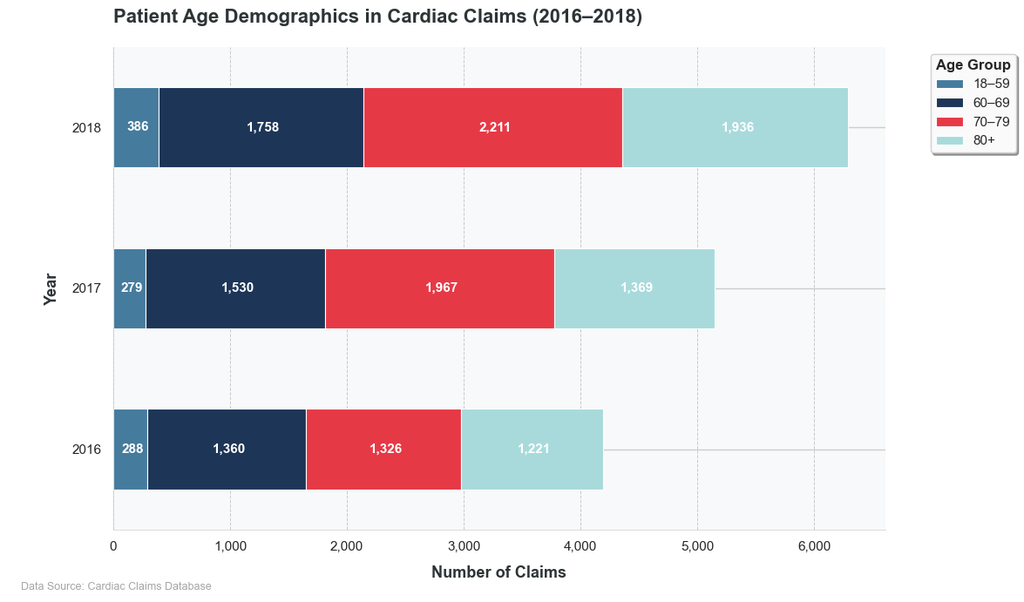

```
📊 Age Group Distribution Summary:
========================================

2016:
  18–59: 288 (6.9%)
  60–69: 1,360 (32.4%)
  70–79: 1,326 (31.6%)
  80+: 1,221 (29.1%)

2017:
  18–59: 279 (5.4%)
  60–69: 1,530 (29.7%)
  70–79: 1,967 (38.2%)
  80+: 1,369 (26.6%)

2018:
  18–59: 386 (6.1%)
  60–69: 1,758 (27.9%)
  70–79: 2,211 (35.1%)
  80+: 1,936 (30.8%)
```

```python
import matplotlib.pyplot as plt
import numpy as np

# Pivot for visualization
age_year_pivot = (
    cardiac_age_claims
    .pivot(index='claim_year', columns='age_group', values='claim_count')
    .fillna(0)
)

# Sophisticated color palette optimized for age groups
colors = ['#457b9d', '#1d3557', '#e63946', '#a8dadc', '#2a9d8f', '#e9c46a']

# Alternative palettes (uncomment to use):
# Warm progression: colors = ['#ff9f1c', '#ffbf69', '#cbf3f0', '#2ec4b6', '#e71d36', '#ff9f1c']
# Cool progression: colors = ['#003f5c', '#58508d', '#bc5090', '#ff6361', '#ffa600', '#488f31']

# Create the figure with better proportions
fig, ax = plt.subplots(figsize=(12, 7))

# Create horizontal stacked bar chart with enhancements
age_year_pivot.plot(
    kind='barh',
    stacked=True,
    color=colors,
    edgecolor='white',
    linewidth=0.8,
    ax=ax
)

# Smart labels with better positioning and contrast
for container in ax.containers:
    labels = []
    for v in container.datavalues:
        if v > max(container.datavalues) * 0.08:  # Dynamic threshold based on segment size
            labels.append(f'{int(v):,}')  # Format with commas for thousands
        else:
            labels.append('')

    ax.bar_label(
        container,
        labels=labels,
        label_type='center',
        fontsize=11,
        fontweight='bold',
        color='white',
        padding=2
    )

# Enhanced chart styling
plt.title(
    'Patient Age Demographics in Cardiac Claims (2016–2018)',
    fontsize=16,
    fontweight='bold',
    pad=20,
    color='#2d3436',
    loc='left'  # Left-aligned title for modern look
)

plt.ylabel('Year', fontsize=13, fontweight='bold', color='#2d3436', labelpad=10)
plt.xlabel('Number of Claims', fontsize=13, fontweight='bold', color='#2d3436', labelpad=10)

# Improved legend
legend = plt.legend(
    title='Age Group',
    bbox_to_anchor=(1.05, 1),
    loc='upper left',
    fontsize=11,
    frameon=True,
    fancybox=True,
    shadow=True,
    framealpha=0.95,
    title_fontsize=12
)
legend.get_title().set_fontweight('bold')

# Enhanced grid
plt.grid(axis='x', linestyle='--', alpha=0.4, color='gray', linewidth=0.7)

# Clean up spines for modern look
ax.spines['top'].set_visible(False)
ax.spines['right'].set_visible(False)
ax.spines['left'].set_linewidth(0.5)
ax.spines['bottom'].set_linewidth(0.5)

# Better tick formatting
plt.xticks(fontsize=11)
plt.yticks(fontsize=11)

# Format x-axis to show thousands with commas
ax.xaxis.set_major_formatter(plt.FuncFormatter(lambda x, p: f'{int(x):,}'))

# Add subtle background
ax.set_facecolor('#f8f9fa')
fig.patch.set_facecolor('white')

# Add data source annotation (optional)
plt.annotate('Data Source: Cardiac Claims Database',
             xy=(0.02, 0.02), xycoords='figure fraction',
             fontsize=9, color='gray', alpha=0.7)

plt.tight_layout()
plt.show()

# Optional: Print summary statistics
print("\n📊 Age Group Distribution Summary:")
print("=" * 40)
for year in age_year_pivot.index:
    year_data = age_year_pivot.loc[year]
    total = year_data.sum()
    print(f"\n{year}:")
    for age_group in age_year_pivot.columns:
        count = year_data[age_group]
        percentage = (count / total) * 100
        print(f"  {age_group}: {count:,} ({percentage:.1f}%)")
```

From 2016 to 2018, the majority of cardiac claims were driven by patients aged 60–79, reaffirming this age group’s dominant role in cardiovascular care demand. This aligns with well-established risk profiles and suggests that clinical capacity, marketing efforts, and community programs should remain centered around this cohort. Meanwhile, the 80+ age group showed steady growth in claim volume, indicating both improved survival and broader care access. This trend calls for investment in geriatric-focused cardiac care — including telehealth, post-acute continuity, and partnerships with long-term care providers.